# Case Study: Improving Term Deposit Client Base

Emily Dale

April 22, 2017

# Background

Hometown Bank has a goal of understanding and improving its status in the term deposit market. To help them reach this goal, I will study the provided data and recommend actions to gain new customers in the term deposit market.

# Data Overview

Hometown Bank provided a dataset with information on 45,211 clients. Each client has the following features listed: * Age * Job * Marital Status * Education * Credit Default (yes/no) * Average Yearly Balance * Housing Loan (yes/no) * Personal Loan (yes/no) * Contact Type * Last Day of Contact * Last Month of Contact * Last Duration of Contact * Number of Contacts During Campaign * Days Since Contact from Last Campaign * Number of Previous Contacts * Outcome of Previous Campaign * Target Outcome: Has the client subscribed to a term deposit? (yes/no)

By studying the first 16 features for each client and whether or not they eventually subscribe to a term deposit, I will be able to make recommendations for a more targeted marketing campaign.

# Data Preparation

Before studying the data further, it first must be prepared. I will outline every transformation and why it has occurred as this case study progresses.

### Examine Data

First, I want to see characteristics for each feature in the dataset so I have a better understanding of the client base.

```r
summary(bank)
```

```
##   age..number        job..category  marital..category education..category
##  Min.   :18.00   blue-collar:9732   divorced: 5207    primary  : 6851
##  1st Qu.:33.00   management :9458   married :27214    secondary:23202
##  Median :39.00   technician :7597   single  :12790    tertiary :13301
##  Mean   :40.94   admin.     :5171                     unknown  : 1857
##  3rd Qu.:48.00   services   :4154
##  Max.   :95.00   retired    :2264
##                  (Other)    :6835
##  default..category balance..number  housing..category loan..category
##  no :44396         Min.   : -8019   no :20081         no :37967
##  yes:  815         1st Qu.:    72   yes:25130         yes: 7244
##                    Median :   448
##                    Mean   :  1362
##                    3rd Qu.:  1428
##                    Max.   :102127
##
##  contact..category  day..number    month..category duration..number
##  cellular :29285   Min.   : 1.00   may    :13766   Min.   :   0.0
##  telephone: 2906   1st Qu.: 8.00   jul    : 6895   1st Qu.: 103.0
##  unknown  :13020   Median :16.00   aug    : 6247   Median : 180.0
##                    Mean   :15.81   jun    : 5341   Mean   : 258.2
##                    3rd Qu.:21.00   nov    : 3970   3rd Qu.: 319.0
##                    Max.   :31.00   apr    : 2932   Max.   :4918.0
##                                    (Other): 6060
##  campaign..number pdays..number   previous..number   poutcome..category
##  Min.   : 1.000   Min.   : -1.0   Min.   :  0.0000   failure: 4901
##  1st Qu.: 1.000   1st Qu.: -1.0   1st Qu.:  0.0000   other  : 1840
##  Median : 2.000   Median : -1.0   Median :  0.0000   success: 1511
##  Mean   : 2.764   Mean   : 40.2   Mean   :  0.5803   unknown:36959
##  3rd Qu.: 3.000   3rd Qu.: -1.0   3rd Qu.:  0.0000
##  Max.   :63.000   Max.   :871.0   Max.   :275.0000
##
##  y..category
##  no :39922
##  yes: 5289
##
##
##
##
##
```

Clients range from 18 to 95 years of age, but the average age is around 41. An interesting tidbit gained from this involve previous contacts during campaigns: most clients have never been contacted for a campaign, but some have been contacted up to 275 times. It will be interesting to see if this has an impact on whether or not they subscribe to a term deposit.

# Explore Client Information

While it’s great to know the average client age and that the majority of clients are married, it will be more informative to learn if there are clusters or segments of the population that are similar. By segmenting the population, we aren’t specifically looking at whether or not they subscribed to a term deposit, but rather if there are “types” of clients. This will help gain a better understanding of Hometown Bank clients and potentially lead to more precise recommendations.

```r
bankCluster <- bank
names(bankCluster)
```

```
##  [1] "age..number"         "job..category"       "marital..category"
##  [4] "education..category" "default..category"   "balance..number"
##  [7] "housing..category"   "loan..category"      "contact..category"
## [10] "day..number"         "month..category"     "duration..number"
## [13] "campaign..number"    "pdays..number"       "previous..number"
## [16] "poutcome..category"  "y..category"
```

#### Segmentation Preparation

Before segmenting the client population, I will first transform the data to reflect client categories. For example, instead of having one age column, I will create age brackets like 18-24, 25-34, and so on. I will also only focus on features specific to the customer like occupation and education rather than campaign information such as previous campaign outcome.The purpose of this method is not to make predictions, but more to explore the population.

Next, transformations. Age, Occupation, Marital Status, and Education are all put into categories.

Age: * 18-24 * 25-34 * 35-44 * 45-54 * 55-64 * 65+

```r
bankCluster$Age18_24 <- ifelse(bankCluster$age..number < 25 & bankCluster$age..number >= 18, 1, 0)
bankCluster$Age25_34 <- ifelse(bankCluster$age..number < 35 & bankCluster$age..number >= 25, 1, 0)
bankCluster$Age35_44 <- ifelse(bankCluster$age..number < 45 & bankCluster$age..number >= 35, 1, 0)
bankCluster$Age45_54 <- ifelse(bankCluster$age..number < 55 & bankCluster$age..number >= 45, 1, 0)
bankCluster$Age55_64 <- ifelse(bankCluster$age..number < 65 & bankCluster$age..number >= 55, 1, 0)
bankCluster$age..number <- NULL
```

Education: * Primary * Secondary * Tertiary * Unknown

```r
bankCluster$eduPrimary <- ifelse(bankCluster$education..category == "primary", 1, 0)
bankCluster$eduSecondary <- ifelse(bankCluster$education..category == "secondary", 1, 0)
bankCluster$eduTertiary <- ifelse(bankCluster$education..category == "tertiary", 1, 0)
bankCluster$education..category <- NULL
```

Occupation: * Administration * Blue Collar * Entrepreneur * Housemaid * Management * Retired * Self-Employed * Services * Student * Technician * Unemployed * Unknown

```r
bankCluster$admin <- ifelse(bankCluster$job..category == "admin", 1, 0)
bankCluster$blueCollar <- ifelse(bankCluster$job..category == "blue-collar", 1, 0)
bankCluster$entrepreneur <- ifelse(bankCluster$job..category == "entrepreneur",1, 0)
bankCluster$housemaid <- ifelse(bankCluster$job..category == "housemaid", 1, 0)
bankCluster$management <- ifelse(bankCluster$job..category == "management", 1, 0)
bankCluster$retired <- ifelse(bankCluster$job..category == "retired", 1, 0)
bankCluster$selfEmployed <- ifelse(bankCluster$job..category == "self-employed", 1, 0)
bankCluster$services <- ifelse(bankCluster$job..category == "services", 1, 0)
bankCluster$student <- ifelse(bankCluster$job..category == "student", 1, 0)
bankCluster$technician <- ifelse(bankCluster$job..category == "technician", 1, 0)
bankCluster$unemployed <- ifelse(bankCluster$job..category == "unemployed", 1, 0)
bankCluster$job..category <-NULL
```

Marital Status: * Divorced * Married * Single

```r
bankCluster$married <- ifelse(bankCluster$marital..category == "married", 1, 0)
bankCluster$single <- ifelse(bankCluster$marital..category == "single", 1, 0)
bankCluster$marital..category <- NULL
```

Finally, information on defaults, the outcome, and housing and personal loans will be changed from “Yes” and “No” to 1 and 0. This does not change the content of the data but does make it easier to interpret.

```r
bankCluster$homeLoan <- ifelse(bankCluster$housing..category == "yes", 1, 0)
bankCluster$housing..category <- NULL
```

```r
bankCluster$defaultYes <- ifelse(bankCluster$default..category == "yes", 1, 0)
bankCluster$default..category <- NULL
```

```r
bankCluster$personalLoan <- ifelse(bankCluster$loan..category == "yes", 1, 0)
bankCluster$loan..category <- NULL
```

```r
bankCluster$subscriber <- ifelse(bankCluster$y..category == "yes", 1, 0)
bankCluster$y..category <- NULL
```

Because I am only looking at client characteristics, I will remove information about the campaign.

```r
bankCluster <- bankCluster[, -c(1:9)]
```

```r
summary(bankCluster)
```

```
##     Age18_24          Age25_34         Age35_44         Age45_54
##  Min.   :0.00000   Min.   :0.0000   Min.   :0.0000   Min.   :0.0000
##  1st Qu.:0.00000   1st Qu.:0.0000   1st Qu.:0.0000   1st Qu.:0.0000
##  Median :0.00000   Median :0.0000   Median :0.0000   Median :0.0000
##  Mean   :0.01789   Mean   :0.3142   Mean   :0.3215   Mean   :0.2203
##  3rd Qu.:0.00000   3rd Qu.:1.0000   3rd Qu.:1.0000   3rd Qu.:0.0000
##  Max.   :1.00000   Max.   :1.0000   Max.   :1.0000   Max.   :1.0000
##     Age55_64        eduPrimary      eduSecondary     eduTertiary
##  Min.   :0.0000   Min.   :0.0000   Min.   :0.0000   Min.   :0.0000
##  1st Qu.:0.0000   1st Qu.:0.0000   1st Qu.:0.0000   1st Qu.:0.0000
##  Median :0.0000   Median :0.0000   Median :1.0000   Median :0.0000
##  Mean   :0.1083   Mean   :0.1515   Mean   :0.5132   Mean   :0.2942
##  3rd Qu.:0.0000   3rd Qu.:0.0000   3rd Qu.:1.0000   3rd Qu.:1.0000
##  Max.   :1.0000   Max.   :1.0000   Max.   :1.0000   Max.   :1.0000
##      admin     blueCollar      entrepreneur       housemaid
##  Min.   :0   Min.   :0.0000   Min.   :0.00000   Min.   :0.00000
##  1st Qu.:0   1st Qu.:0.0000   1st Qu.:0.00000   1st Qu.:0.00000
##  Median :0   Median :0.0000   Median :0.00000   Median :0.00000
##  Mean   :0   Mean   :0.2153   Mean   :0.03289   Mean   :0.02743
##  3rd Qu.:0   3rd Qu.:0.0000   3rd Qu.:0.00000   3rd Qu.:0.00000
##  Max.   :0   Max.   :1.0000   Max.   :1.00000   Max.   :1.00000
##    management        retired         selfEmployed        services
##  Min.   :0.0000   Min.   :0.00000   Min.   :0.00000   Min.   :0.00000
##  1st Qu.:0.0000   1st Qu.:0.00000   1st Qu.:0.00000   1st Qu.:0.00000
##  Median :0.0000   Median :0.00000   Median :0.00000   Median :0.00000
##  Mean   :0.2092   Mean   :0.05008   Mean   :0.03493   Mean   :0.09188
##  3rd Qu.:0.0000   3rd Qu.:0.00000   3rd Qu.:0.00000   3rd Qu.:0.00000
##  Max.   :1.0000   Max.   :1.00000   Max.   :1.00000   Max.   :1.00000
##     student          technician      unemployed         married
##  Min.   :0.00000   Min.   :0.000   Min.   :0.00000   Min.   :0.0000
##  1st Qu.:0.00000   1st Qu.:0.000   1st Qu.:0.00000   1st Qu.:0.0000
##  Median :0.00000   Median :0.000   Median :0.00000   Median :1.0000
##  Mean   :0.02075   Mean   :0.168   Mean   :0.02882   Mean   :0.6019
##  3rd Qu.:0.00000   3rd Qu.:0.000   3rd Qu.:0.00000   3rd Qu.:1.0000
##  Max.   :1.00000   Max.   :1.000   Max.   :1.00000   Max.   :1.0000
##      single          homeLoan        defaultYes       personalLoan
##  Min.   :0.0000   Min.   :0.0000   Min.   :0.00000   Min.   :0.0000
##  1st Qu.:0.0000   1st Qu.:0.0000   1st Qu.:0.00000   1st Qu.:0.0000
##  Median :0.0000   Median :1.0000   Median :0.00000   Median :0.0000
##  Mean   :0.2829   Mean   :0.5558   Mean   :0.01803   Mean   :0.1602
##  3rd Qu.:1.0000   3rd Qu.:1.0000   3rd Qu.:0.00000   3rd Qu.:0.0000
##  Max.   :1.0000   Max.   :1.0000   Max.   :1.00000   Max.   :1.0000
##    subscriber
##  Min.   :0.000
##  1st Qu.:0.000
##  Median :0.000
##  Mean   :0.117
##  3rd Qu.:0.000
##  Max.   :1.000
```

Next for the actual customer segmentation. If we grouped all clients into 2 groups, what would be the characteristics of those two groups?

```r
set.seed(1234)
bank_cluster_2 <- kmeans(bankCluster, centers=2)
Clusters_2<-data.frame(bank_cluster_2$centers)
bank_cluster_2$size
```

```
## [1] 31719 13492
```

70.2% of clients are in Group 1 and 29.8% are in Group 2. Let’s take a look at those two groups.

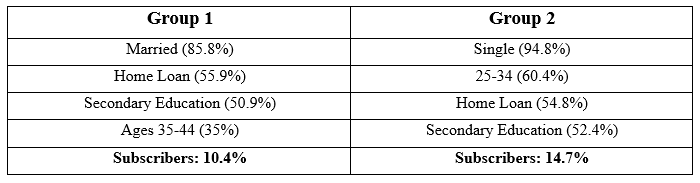

*Characteristics of Hometown Bank’s Two Primary Groups*

As you can see, the clients split nicely into two groups. Group 1 are your established adults. 35% of the clients in this group are between the ages of 35 and 44, most are married, and the majority have a home loan. Of the 31,719 clients in Group 1, 10.4% subscribed to a term deposit.

By grouping clients, it is easier to get an idea of who Hometown Bank will be advertising to and some information about them. This also helps differentiate two different marketing campaigns: * When advertising for Group 1, it would be best to use tie-ins to family life. For example, encourage customers to purchase a term deposit for their children as a guarantee for college. * When advertising for Group 2, think of the young adults that are in the group. Ads should focus on tasks that occur while becoming established: purchasing a home or putting away money for future home renovations or a wedding.

By knowing Hometown Bank’s audience, marketing can be more directed.

# Decision Tree

Next I want to see which factors indicate whether or not a customer will subcribe to a term deposit. One technique is called a *decision tree*. With a decision tree, the most important factor is revealed, with other factors branching out from under the original. The tree is a series of yes/no questions that provide a map to whether or not the customer is likely to subscribe.

For this method, the data is first split into two sets: training and testing. The model will be “learned” from the training set, finding patterns in the data. Next, the test set will be put through the tree and predictions will be made for each customer. Finally, the tree will be evaluated. I will compare the predicted value vs. the actual value for each customer to score the tree on its performance.

### Tree Preparation

```r
set.seed(1234)
library(caTools)
bank$spl <- sample.split(bank[,1], SplitRatio = 0.7)
```

```r
bank_train <- subset(bank, bank$spl ==TRUE)
bank_test <- subset(bank, bank$spl==FALSE)
```

```r
bank_train$spl <- NULL
bank_test$spl <-NULL
```

### Build Tree

```r
library(rpart)
set.seed=1234
bank_rpart <- rpart(bank_train$y..category~., method="class", parms = list(split="gini"), data=bank_train)
```

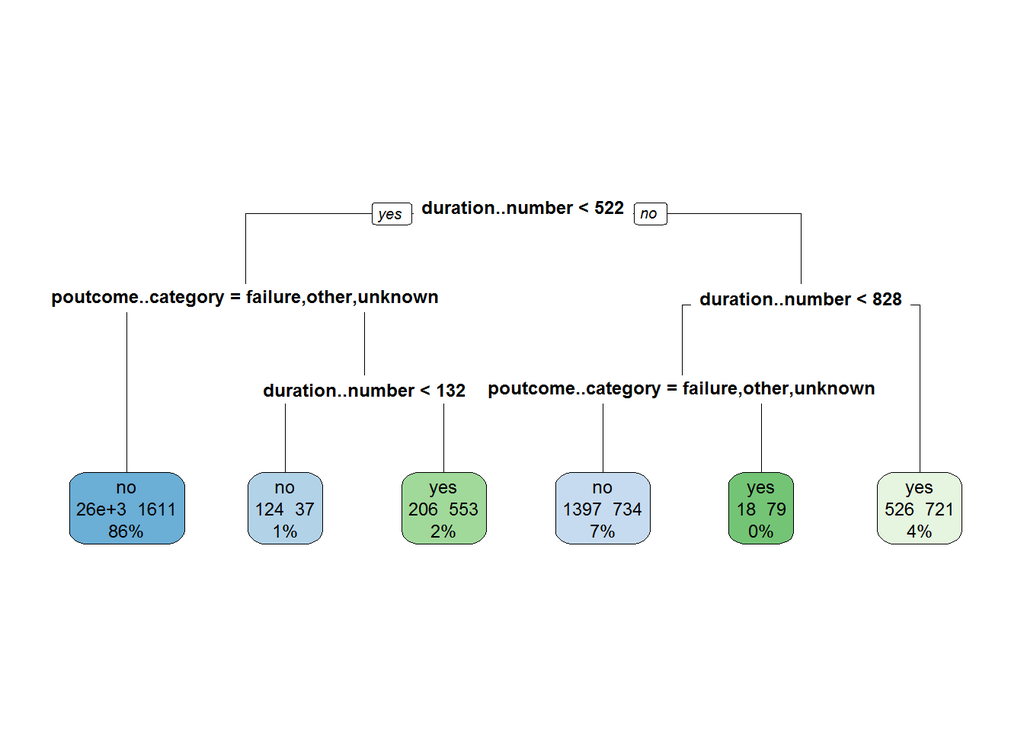

```r
library(rpart.plot)
rpart.plot(bank_rpart, type=0, extra=101)
```

This decision tree shows that those customers more likely to subcribe are: * those whose contact was 132-522 seconds long and whose last outcome was successful. * those whose contact was greater than 828 seconds. * those whose contact was 522-828 seconds long and whose last outcome was successful.

```r
library(caret)
actual <- bank_test$y..category
predicted <- predict(bank_rpart, bank_test, type="class")
results.matrix <- confusionMatrix(predicted, actual, positive="yes")
print(results.matrix)
```

```
## Confusion Matrix and Statistics
##
##           Reference
## Prediction    no   yes
##        no  11684  1003
##        yes   328   551
##
##                Accuracy : 0.9019
##                  95% CI : (0.8968, 0.9068)
##     No Information Rate : 0.8854
##     P-Value [Acc > NIR] : 4.457e-10
##
##                   Kappa : 0.4036
##  Mcnemar's Test P-Value : < 2.2e-16
##
##             Sensitivity : 0.35457
##             Specificity : 0.97269
##          Pos Pred Value : 0.62685
##          Neg Pred Value : 0.92094
##              Prevalence : 0.11455
##          Detection Rate : 0.04062
##    Detection Prevalence : 0.06479
##       Balanced Accuracy : 0.66363
##
##        'Positive' Class : yes
##
```

### Tree Adjustments

Here I am making minor adjustments to the tree to make it simpler.

```r
cptable <- printcp(bank_rpart)
```

```
##
## Classification tree:
## rpart(formula = bank_train$y..category ~ ., data = bank_train,
##     method = "class", parms = list(split = "gini"))
##
## Variables actually used in tree construction:
## [1] duration..number   poutcome..category
##
## Root node error: 3735/31645 = 0.11803
##
## n= 31645
##
##         CP nsplit rel error  xerror     xstd
## 1 0.040607      0   1.00000 1.00000 0.015367
## 2 0.023293      3   0.87818 0.91620 0.014791
## 3 0.016332      4   0.85489 0.86212 0.014399
## 4 0.010000      5   0.83855 0.85087 0.014315
```

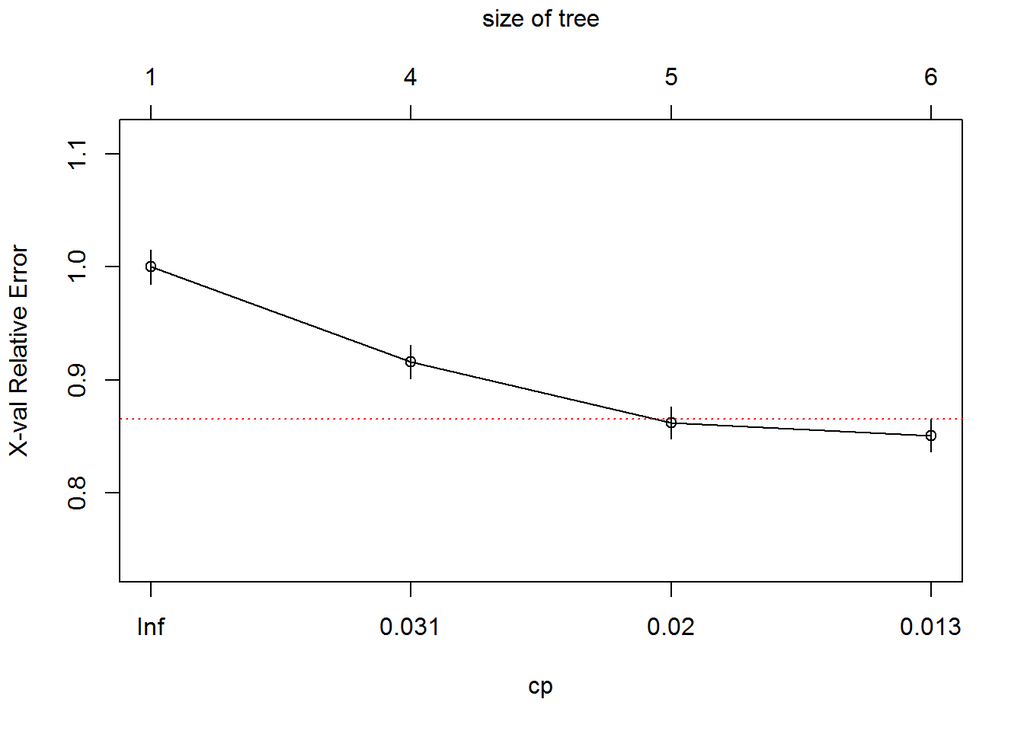

```r
plotcp(bank_rpart, minline=TRUE, col="red")
```

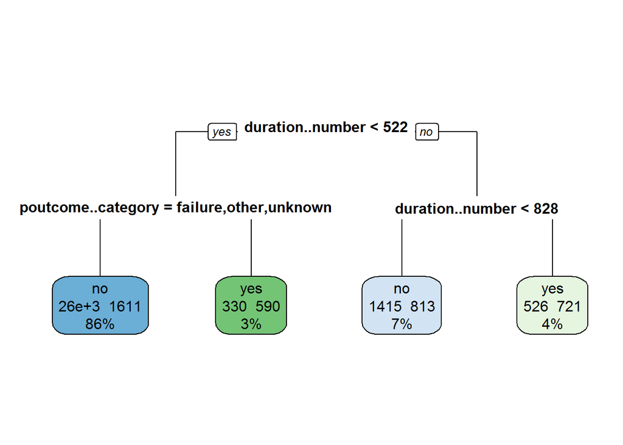

```r
pruned_bank_rpart <- prune(bank_rpart, cp=.031)
rpart.plot(pruned_bank_rpart, type=0, extra=101)
```

```r
actual <- bank_test$y..category
predicted <- predict(pruned_bank_rpart, bank_test, type="class")
results.matrix <- confusionMatrix(predicted, actual, positive="yes")
print(results.matrix)
```

```
## Confusion Matrix and Statistics
##
##           Reference
## Prediction    no   yes
##        no  11630  1024
##        yes   382   530
##
##                Accuracy : 0.8964
##                  95% CI : (0.8911, 0.9014)
##     No Information Rate : 0.8854
##     P-Value [Acc > NIR] : 2.789e-05
##
##                   Kappa : 0.3771
##  Mcnemar's Test P-Value : < 2.2e-16
##
##             Sensitivity : 0.34106
##             Specificity : 0.96820
##          Pos Pred Value : 0.58114
##          Neg Pred Value : 0.91908
##              Prevalence : 0.11455
##          Detection Rate : 0.03907
##    Detection Prevalence : 0.06723
##       Balanced Accuracy : 0.65463
##
##        'Positive' Class : yes
##
```

After those adjustments, we lose a slight bit of accuracy but overall the tree is just as effective. This tree is much simpler to use than the original, making it easy to use in the future.

With this tree, the customers most likely to subscribe to a term deposit are: * those whose contact was greater than 828 seconds (about 14 minutes) * those whose contact was less than 522 seconds (almost 9 minutes) and whose previous campaign was successful

# Random Forest

My final method is called a *Random Forest*. The strategy here is to make a tree like above, but over and over. By creating hundreds of trees and then finding the most frequent prediction among the trees, Hometown Bank will have a model that can predict which customers will subscribe to a term deposit very effectively.

```r
library(randomForest)
bank.rForest <- randomForest(y..category~., data=bank_train, mtry=3, ntree=500, na.action = na.omit, importance=TRUE)
print(bank.rForest)
```

```
##
## Call:
##  randomForest(formula = y..category ~ ., data = bank_train, mtry = 3,      ntree = 500, importance = TRUE, na.action = na.omit)
##                Type of random forest: classification
##                      Number of trees: 500
## No. of variables tried at each split: 3
##
##         OOB estimate of  error rate: 9.25%
## Confusion matrix:
##        no  yes class.error
## no  27046  864  0.03095665
## yes  2064 1671  0.55261044
```

With this method the output isn’t a tree like before, but a list of factors that are the most important.

```r
importance(bank.rForest)
```

```
##                             no        yes MeanDecreaseAccuracy
## age..number          43.928351  10.705723            45.134590
## job..category        32.137619  -4.597198            25.584284
## marital..category     7.278076   7.249659            10.787270
## education..category  17.214594   2.782676            17.335461
## default..category     2.104665   3.445284             3.549528
## balance..number       9.118375   8.508260            13.099675
## housing..category    39.792660  17.882429            44.387322
## loan..category        1.482811  14.614789            10.524446
## contact..category    43.977984   9.575951            46.200439
## day..number          55.161351   2.625701            55.662021
## month..category      83.888094  27.855862            88.565839
## duration..number    126.676826 180.879487           181.824895
## campaign..number     21.427182  12.231476            25.198445
## pdays..number        25.267763  20.033740            27.487481
## previous..number     18.965480  12.256515            19.232253
## poutcome..category   37.379006  16.024978            52.126155
##                     MeanDecreaseGini
## age..number                528.14317
## job..category              389.90826
## marital..category          117.57688
## education..category        145.69556
## default..category           10.88319
## balance..number            554.65588
## housing..category          121.80085
## loan..category              48.78916
## contact..category          121.64802
## day..number                468.10494
## month..category            739.41402
## duration..number          1672.41651
## campaign..number           218.14502
## pdays..number              281.23267
## previous..number           144.52340
## poutcome..category         428.60327
```

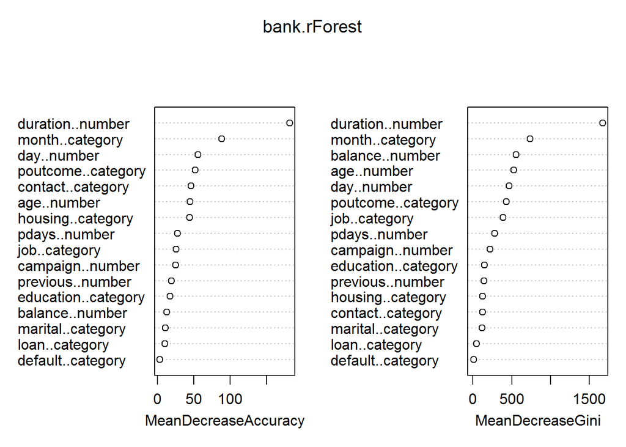

```r
varImpPlot(bank.rForest)
```

Duration has the highest importance, meaning it is the most important factor in determining who will subscribe.

The importance chart shows how much specific factors contribute to the overall prediction. As you can see, duration exceeds all other factors in contributing, and could potentially be the sole factor used in determining who will subscribe.

Finally, let’s score this model to see how it performed.

```r
actual <- bank_train$y..category
bank_predicted <- predict(bank.rForest, newdata=bank_train, type="class")
bank_results.matrix.rf <- confusionMatrix(bank_predicted, actual, positive="yes")
print(bank_results.matrix.rf)
```

```
## Confusion Matrix and Statistics
##
##           Reference
## Prediction    no   yes
##        no  27910   154
##        yes     0  3581
##
##                Accuracy : 0.9951
##                  95% CI : (0.9943, 0.9959)
##     No Information Rate : 0.882
##     P-Value [Acc > NIR] : < 2.2e-16
##
##                   Kappa : 0.9762
##  Mcnemar's Test P-Value : < 2.2e-16
##
##             Sensitivity : 0.9588
##             Specificity : 1.0000
##          Pos Pred Value : 1.0000
##          Neg Pred Value : 0.9945
##              Prevalence : 0.1180
##          Detection Rate : 0.1132
##    Detection Prevalence : 0.1132
##       Balanced Accuracy : 0.9794
##
##        'Positive' Class : yes
##
```

This model was correct 99.51% of the time! More importantly, the model was able to find every customer that did not subscribe to a term deposit (100% of the time), meaning it can be used to eliminate customers who shouldn’t be targeted.

# Recommendations

Customers that previously signed up for at term deposit were more likely to subscribe again. That’s something to be proud of! Hometown Bank has provided customer service that encourages clients to subscribe again. Special notice should be given to past subscribers, possibly with special perks for repeat subscribers.

Finally, Hometown Bank should be mindful of its audience when marketing for this campaign. The clients split into two categories: Established Adults and Young Adults. By knowing each audience’s needs, Hometown Bank will likely increase its term deposit subscribers.